# Baza konfliktów - obróbka danych w R

Tomasz Stąpor

30 września 2014

## Wstęp

Opis procedury odpytania bazy konfliktów militarnych [UCDP/PRIO Armed Conflict Dataset v.4-2014, 1946 – 2013](http://www.pcr.uu.se/research/ucdp/datasets/ucdp_prio_armed_conflict_dataset/) o dokładne daty początku 159 konfliktów. Baza zawiera 254 konfliky oraz ich rozwój w kolejnych latach. Każdy rok konfliktu to kolejny rekord w bazie. Wszystkich rekordów jest 2134. Dokładny opis bazy danych wraz z wyjaśnieniem poszczególnych zmiennych znajduje się w [Codebook](http://www.pcr.uu.se/digitalAssets/124/124920_1codebook_ucdp_prio-armed-conflict-dataset-v4_2014.pdf).

## Baza danych

Cała baza składa się z 27 kolumn, które są opisane w Codebook. Na potrzeby zadania w dalszej pracy korzystam jedynie z kilku kolumn tej bazy:

```r
  # Pobranie pliku bazy
  load("data/124920_1ucdpprioarmedconflictdataset4.2014.rdata")
  # Wybieram jedynie parę kolumn
  data <- subset(ucdpConflict, select=c(ConflictId,Location,Year,StartDate,StartPrec))
  # Drukuję pierwszych 6 rekordów
  head(data)
```

```
##   ConflictId             Location Year  StartDate StartPrec
## 1        1-1              Bolivia 1946 1946-06-30         4
## 2        1-1              Bolivia 1952 1946-06-30         4
## 3        1-1              Bolivia 1967 1946-06-30         4
## 4        1-2 Cambodia (Kampuchea) 1946 1946-08-31         3
## 5        1-2 Cambodia (Kampuchea) 1947 1946-08-31         3
## 6        1-2 Cambodia (Kampuchea) 1948 1946-08-31         3
```

Poniżej opis kolumn z bazy, którymi się interesowałem:

- `ConflictId` - Każdy konflit ma swój unikalny numer Id.
- `Year` - Konflikt może ciągnąć się latami, dlatego gdy w danym roku zaobserwuje się conajmniej 25 ofiar śmiertelnych w konflikcie to pojawia się nowy rekord. Kolumna *Year* pokazuje, jak konflikt rozwija się w kolejnych latach.
- `StartDate` - Data pojawienia się pierwszej ofiary śmiertelnej.
- `StartPrec` - Dokładność daty w *StartDate*. 1 - Data dokładna co do dnia. 2 - dokładna co do miesiąca, etc..

### Ilość konfliktów a rekordy

Mamy 2134 rekordy w bazie danych oraz 254 konflikty. Różnica wynika z tego, że jeden konflikt może ciągnąć się latami, co jest pokazane w bazie za pomocą kolejnych rekordów.

```r
  # Ilość rekordów
  nrow(data)
```

```
## [1] 2134
```

```r
  # Ilość konfliktów. Zliczenie wszystkich unikalnych ConflictId
  length(table(data$ConflictId))
```

```
## [1] 254
```

## Wybór dokładnych dat

Wybieram jedynie te rekordy, których `StartPrec == 1`, a więc data pojawienia się pierwszej ofiary śmiertelnej konfliktu zmienna `StartDate` jest dokładnie znana:

```r
  # Pobranie wierszy ze StartPrec == 1 oraz wskazanych kolumn z bazy
  data  <- subset(ucdpConflict, StartPrec == 1, select=c(ConflictId,Location,Year,StartDate,StartPrec))
  # Wydruk kontrolny, pierwsze 4 wiersze
  head(data,4)
```

```
##     ConflictId                Location Year  StartDate StartPrec
## 41         1-7                    Iran 1946 1945-11-19         1
## 115       1-15        France, Thailand 1946 1946-05-07         1
## 116       1-16 Albania, United Kingdom 1946 1946-10-22         1
## 117       1-17 Vietnam (North Vietnam) 1946 1946-11-20         1
```

```r
  # Zliczenie wierszy i kolumn
  dim(data)
```

```
## [1] 1163    5
```

## 159 dokładnych dat

Wierszy z poprzedniego zliczenia jest 1163, gdyż baza przedstawia również kolejne lata konfliktu. Dlatego dokonuję zliczenia wszystkich rekordów na podstawie kolumny `StartDate`. Wszystkich dat jest:

```r
  length(table(data$StartDate))
```

```
## [1] 159
```

### Histogram

Graficzne przedstawienie 159 dat na osi czsu. Na osi *y* ilość lat konfliktu, którego początek jest przedstawiony na osi *x*.

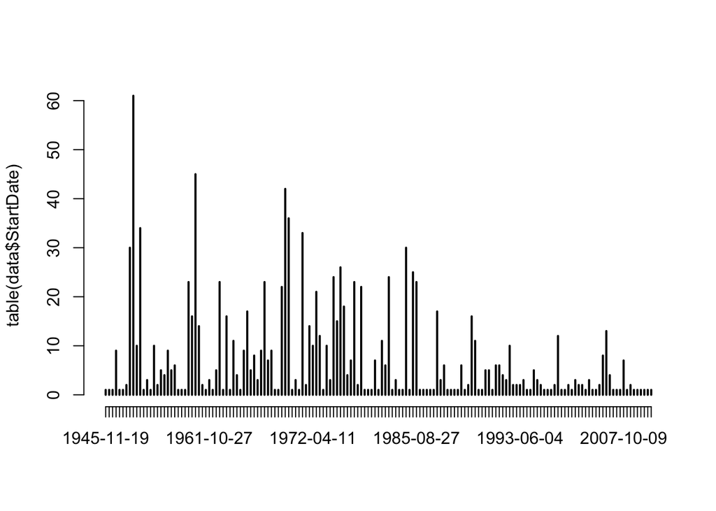

```r
  plot(table(data$StartDate))
```

### Lista wszystkich dat

Lista wszystkich dat na podstawie ktorej został wygenerowany powyższy histogram.

```r
  data.frame(table(data$StartDate))
```

```
##           Var1 Freq
## 1   1945-11-19    1
## 2   1946-05-07    1
## 3   1946-10-22    1
## 4   1946-11-20    9
## 5   1947-02-28    1
## 6   1947-03-29    1
## 7   1948-04-15    2
## 8   1948-05-01   30
## 9   1948-05-15   61
## 10  1948-06-19   10
## 11  1949-07-18   34
## 12  1950-08-05    1
## 13  1950-10-07    3
## 14  1950-10-30    1
```

[output cut: 145 more lines]